# Final exam

Utkarsha Vidhale

Nov 27th, 2020.

# Instructions

*Some standard writing considerations:* Replace comments that instruct you to put code with your own code. Ensure your plots and output are visible and readable. Ensure you’ve typed up an explanation of your answers wherever required.

- *Format*: delete **all** comments and replace with your answers and code.
- *Name*: do not forget to put your name on the exam under the ‘author’ heading.
- *Submission*: your submission must consist of your copy of this Markdown document *and* a knitted `html` file. Any other type of submission will receive no credit and no opportunity for a re-submission.
- *Issues*: In case of extreme / unusual difficulties related to the pandemic or health otherwise, please contact the instructor as soon as possible to try to reschedule the interrupted exam or otherwise resolve the issue. Late submissions are not accepted otherwise.
- This is a 2-hour exam. You may take about *3 hours* to complete it. These three hours need to be *consecutive*, but can be chosen at your convenience between 14:00hrs Central Time on Friday 27th November and *two hours prior to your scheduled* oral exam time.
- Exam must be submitted on Google classroom.
- You must sign up for the virtual meeting via the link posted on Campuswire post #204.

## Honor code

> I pledge on this day, 12/4/2020, not to use any book, website, or other online source to solve the midterm problems. I will not use any additional technology other than my local installation of R (Python if applicable) and RStudio (or similar) that I’m using to knit Markdown documents. I will not give or receive information to or from any other persons during this midterm. This document was edited and PDF knitted by me alone.

*UTKARSHA VIDHALE*

## Grading and rubric

Here is how will you be graded on the final exam:

- 100 points total, broken up as follows:
- 80 points for complete solutions to the given problems submitted via google classroom;
  - Problems 1-3: 30 points (10 each);
  - Problems 4-5: 30 points (15 each);
  - Problem 6: 20 points;
- 20 points for the virtual exam ”in-person” focusing on one of those problems (that I will choose at random):
  - 5 points for knowledge of problem: being able to complete the solution ”live”;
  - 5 points for completeness: writing up the details so that the statistics behind the solution makes complete sense;
  - 5 points for clarity of exposition and oral explanation;
  - 5 points for being able to answer a related follow-up question (e.g., a more in-depth explanation of a definition or a concept that the problem is about).

# Exam problems

## Problem 1 - Hypothesis tests for regression coefficients

This question is about the `Advertising` data set which we’ve seen extensively in the lectures on regression.

Consider the following table output of the `lm` function:

|  | Coefficient | Std. error | t-statistic | p-value |
| --- | --- | --- | --- | --- |
| Intercept | 2.939 | 0.3119 | 9.42 | <0.0001 |
| TV | 0.046 | 0.0014 | 32.81 | <0.0001 |
| radio | 0.189 | 0.0086 | 21.89 | <0.0001 |
| newspaper | - 0.001 | 0.0059 | -0.18 | 0.8599 |

*Table: For the `Advertising` data, least squares coefficient estimates of the multiple linear regression of number of units sold on `radio`, `TV`, and `newspaper` advertising budgets.*

Describe the null hypotheses to which the p-values given in Table above correspond.

**Answer:**

Null Hypothesis for `TV` : `TV` ads have no effect on sales in presence of `radio` ads and `newspaper` ads.

Null Hypothesis for `radio` : `radio` ads have no effect on sales in presence of `TV` ads and `newspaper` ads.

Null Hypothesis for `newspaper` : `newspaper` ads have no effect on sales in presence of `radio` ads and `TV` ads.

Explain what conclusions you can draw based on these p-values. Your explanation should be phrased in terms of `sales`, `TV`, `radio`, and `newspaper`, rather than in terms of the coefficients of the linear model.

**Answer:**

The p-value of `TV` and `radio` is `<0.0001` which is (less than `0.05`) significantly low. This suggests that there is enough evidence to reject Null Hypothesis for `TV` and `radio`.

The p-value for `newspaper` is `0.8599` which is (more than `0.05`) significantly high. This suggests that there is no enough evidence to reject Null Hypothesis for `newspaper`.

## Problem 2 - a regression puzzle

Suppose we have a data set with five predictors, $X_1 =$GPA, $X_2 =$ IQ, $X_3 =$ Gender (0 for Male and 1 for not Male), $X_4$ = Interaction between GPA and IQ, and $X_5$ = Interaction between GPA and Gender. The response is starting salary after graduation (in thousands of dollars).

Suppose we use least squares to fit the model, and get:
$$\hat\beta_0 = 50, \quad \hat\beta_1 =20, \quad \hat\beta_2 = 0.07, \quad \hat\beta_3 = 35, \quad \hat\beta_4 = 0.01, \quad \hat\beta_5 = −10.$$

  **Answer:** Incorrect

  **Answer:** Incorrect

  **Answer:** Correct

  **Answer:** Incorrect

**Answer:** Salary of a non-male with IQ of 110 and a GPA of 4.0 = 137100

```
 The equation for salary:
 Salary = 50 + 20GPA + 0.07IQ + 35Gender + 0.01(GPA * IQ) - 10(GPA * Gender)
 For `Gender` = Female (1), `IQ` = 110, `GPA` = 4.0,
 Salary = 50 +20GPA + 0.07IQ + 35 + 0.01(GPA * IQ) -10(GPA)
 Salary = 50 + 20(4.0) + 0.07(110) +35 + 0.01(4.0 * 110) - 10(4.0)
```

```r
GPA = 4.0
IQ = 110
Salary = (50 +(20*GPA) + (0.07*IQ) + 35 + (0.01*GPA * IQ) - (10*4.0))
Salary
```

```
## [1] 137.1
```

```
salary of a non-male with IQ of 110 and a GPA of 4.0 = 137.1 thousand dollars
```

- True or false: Since the coefficient for the GPA/IQ interaction term is very small, there is very little evidence of an interaction effect. Justify your answer.

**Answer:** False.

```
In order to determine if the interaction term is statistically significant or not, we need to examine:
the hypothesis $H_0:\quad \hat\beta_4 = 0$ and look at the p-value associated with the statistics;
or
the p-value of the regression coefficient.
```

## Problem 3 - Training and testing RSS

This problem is about comparing linear (restrictive) and nonlinear (flexible) models using the training and testing residual sum of squares.

I collect a set of data (n = 100 observations) containing a single predictor and a quantitative response. I then fit a linear regression model to the data, as well as a separate cubic regression, i.e. $Y=\beta_0+\beta_1X+\beta_2X^2+\beta_3X^3+\epsilon$.

- Suppose that the true relationship between X and Y is linear, i.e. $Y = \beta_0+\beta_1X+\epsilon$. Consider the training residual sum of squares (RSS) for the linear regression, and also the training RSS for the cubic regression. Would we expect one to be lower than the other, would we expect them to be the same, or is there not enough information to tell? Justify your answer.

  **Answer:** As we use more flexible models, the training RSS decreases, this is simply because it is easier to get the predicted line closer to the observations when there is more flexibility how the output function can conform to the data. Without knowing more details about the training data, it is difficult to know which training RSS is lower between linear or cubic.  
  If the true relationship is linear, than the introduction of the cubic regression would merely introduce excess noise. Therefore, we would expect the training RSS to be lower for the cubic regression than the linear regression.
- Answer the same question as above, but using test rather than training RSS.

  **Answer:** The test RSS depends upon the test data. We may assume that polynomial regression will have a higher test RSS as the overfit from training would have more error than the linear regression.
- Suppose that the true relationship between $X$ and $Y$ is not linear, but we don’t know how far it is from linear. Consider the training RSS for the linear regression, and also the training RSS for the cubic regression. Would we expect one to be lower than the other, would we expect them to be the same, or is there not enough information to tell? Justify your answer.

  **Answer:** Polynomial regression has lower train RSS than the linear fit because of higher flexibility: no matter what the underlying true relationshop is the more flexible model will closer follow points and reduce train RSS.
- Answer the same question as above, but using test rather than training RSS.

  **Answer:** There is not enough information to tell which test RSS would be lower for either regression given the problem statement is defined as not knowing “how far it is from linear”. If it is closer to linear than cubic, the linear regression test RSS could be lower than the cubic regression test RSS. Or, if it is closer to cubic than linear, the cubic regression test RSS could be lower than the linear regression test RSS. It is dues to bias-variance tradeoff: it is not clear what level of flexibility will fit data better.

## Problem 4 - Exploring predictors

This questions involves the `Carseats` data set (from the library `ISLR`, which we’ve used several times in lectures/homework recently).

Run these commands to load the dataset.

```r
require(ISLR)
data(Carseats)
library(dplyr)
```

Before you answer the following, make sure that the missing values have been removed from the data.

```r
sum(is.na.data.frame(Carseats))
```

```
## [1] 0
```

1. Which of the predictors are quantitative (discrete random variables), and which are qualiative (continuous random variables)?

```r
s=summary(Carseats)
s
```

```
##      Sales          CompPrice       Income        Advertising
##  Min.   : 0.000   Min.   : 77   Min.   : 21.00   Min.   : 0.000
##  1st Qu.: 5.390   1st Qu.:115   1st Qu.: 42.75   1st Qu.: 0.000
##  Median : 7.490   Median :125   Median : 69.00   Median : 5.000
##  Mean   : 7.496   Mean   :125   Mean   : 68.66   Mean   : 6.635
##  3rd Qu.: 9.320   3rd Qu.:135   3rd Qu.: 91.00   3rd Qu.:12.000
##  Max.   :16.270   Max.   :175   Max.   :120.00   Max.   :29.000
##    Population        Price        ShelveLoc        Age          Education
##  Min.   : 10.0   Min.   : 24.0   Bad   : 96   Min.   :25.00   Min.   :10.0
##  1st Qu.:139.0   1st Qu.:100.0   Good  : 85   1st Qu.:39.75   1st Qu.:12.0
##  Median :272.0   Median :117.0   Medium:219   Median :54.50   Median :14.0
##  Mean   :264.8   Mean   :115.8                Mean   :53.32   Mean   :13.9
##  3rd Qu.:398.5   3rd Qu.:131.0                3rd Qu.:66.00   3rd Qu.:16.0
##  Max.   :509.0   Max.   :191.0                Max.   :80.00   Max.   :18.0
##  Urban       US
##  No :118   No :142
##  Yes:282   Yes:258
##
##
##
##
```

2. What is the range of each quantitative predictor? You can answer this using the `range()` function.

```r
sale=range(Carseats$Sales)
comp=range(Carseats$CompPrice)
inc=range(Carseats$Income)
price=range(Carseats$Price)
pop=range(Carseats$Population)
adv=range(Carseats$Advertising)
```

**Answer:**

```
Range of Quantitative Predictors:
Sales = 0, 16.27
CompPrice = 77, 175
Income = 21, 120
Price = 24, 191
Population = 10, 509
Advertising = 0, 29
```

3. What is the mean and standard deviation of each quantitative predictor?

```r
sale.sd = sd(Carseats$Sales)
comp.sd = sd(Carseats$CompPrice)
inc.sd = sd(Carseats$Income)
price.sd = sd(Carseats$Price)
pop.sd = sd(Carseats$Population)
adv.sd = sd(Carseats$Advertising)
```

**Answer:**

```
Sales         - Mean   : 7.496    Standard deviation:2.824115
CompPrice     - Mean   :125   Standard deviation: 15.3345115
Income        - Mean   : 68.66   Standard deviation: 27.9860365
Price         - Mean   :115.8   Standard deviation: 23.6766644
Population    - Mean   :264.8   Standard deviation: 147.3764362
Advertising   - Mean   : 6.635   Standard deviation: 6.6503642`
```

4. Now remove the 10th through 85th observations. What is the range, mean, and standard deviation of each predictor in the subset of the data that remains?

```r
SubSet = Carseats[c(10:85),]
Sum= summary(SubSet)
Sum
```

```
##      Sales          CompPrice         Income        Advertising
##  Min.   : 0.910   Min.   : 77.0   Min.   : 25.00   Min.   : 0.000
##  1st Qu.: 4.900   1st Qu.:109.8   1st Qu.: 47.50   1st Qu.: 0.000
##  Median : 7.750   Median :121.0   Median : 72.50   Median : 4.500
##  Mean   : 7.487   Mean   :121.7   Mean   : 70.72   Mean   : 6.395
##  3rd Qu.: 9.220   3rd Qu.:133.2   3rd Qu.: 91.25   3rd Qu.:12.000
##  Max.   :14.900   Max.   :157.0   Max.   :119.00   Max.   :23.000
##    Population        Price         ShelveLoc       Age          Education
##  Min.   : 16.0   Min.   : 24.00   Bad   :22   Min.   :25.00   Min.   :10.00
##  1st Qu.:129.5   1st Qu.: 98.75   Good  :19   1st Qu.:44.00   1st Qu.:12.00
##  Median :236.5   Median :111.50   Medium:35   Median :56.00   Median :15.50
##  Mean   :236.5   Mean   :112.37               Mean   :55.04   Mean   :14.67
##  3rd Qu.:358.2   3rd Qu.:131.00               3rd Qu.:65.00   3rd Qu.:17.00
##  Max.   :508.0   Max.   :154.00               Max.   :80.00   Max.   :18.00
##  Urban      US
##  No :23   No :29
##  Yes:53   Yes:47
##
##
##
##
```

```r
sub_sale=range(SubSet$Sales)
sub_comp=range(SubSet$CompPrice)
sub_inc=range(SubSet$Income)
sub_price=range(SubSet$Price)
sub_pop=range(SubSet$Population)
sub_adv=range(SubSet$Advertising)

sub_sale.sd = sd(SubSet$Sales)
sub_comp.sd = sd(SubSet$CompPrice)
sub_inc.sd = sd(SubSet$Income)
sub_price.sd = sd(SubSet$Price)
sub_pop.sd = sd(SubSet$Population)
sub_adv.sd = sd(SubSet$Advertising)
```

**Answer:**

[output not shown]

5. Using the full data set, investigate the predictors *graphically*, using scatterplots or other tools of your choice. Create some plots highlighting the relationships among the predictors. Comment on your findings.

```r
subset_1= Carseats %>% select(1:6, 8, 9)
summary(subset_1)
```

```
##      Sales          CompPrice       Income        Advertising
##  Min.   : 0.000   Min.   : 77   Min.   : 21.00   Min.   : 0.000
##  1st Qu.: 5.390   1st Qu.:115   1st Qu.: 42.75   1st Qu.: 0.000
##  Median : 7.490   Median :125   Median : 69.00   Median : 5.000
##  Mean   : 7.496   Mean   :125   Mean   : 68.66   Mean   : 6.635
##  3rd Qu.: 9.320   3rd Qu.:135   3rd Qu.: 91.00   3rd Qu.:12.000
##  Max.   :16.270   Max.   :175   Max.   :120.00   Max.   :29.000
##    Population        Price            Age          Education
##  Min.   : 10.0   Min.   : 24.0   Min.   :25.00   Min.   :10.0
##  1st Qu.:139.0   1st Qu.:100.0   1st Qu.:39.75   1st Qu.:12.0
##  Median :272.0   Median :117.0   Median :54.50   Median :14.0
##  Mean   :264.8   Mean   :115.8   Mean   :53.32   Mean   :13.9
##  3rd Qu.:398.5   3rd Qu.:131.0   3rd Qu.:66.00   3rd Qu.:16.0
##  Max.   :509.0   Max.   :191.0   Max.   :80.00   Max.   :18.0
```

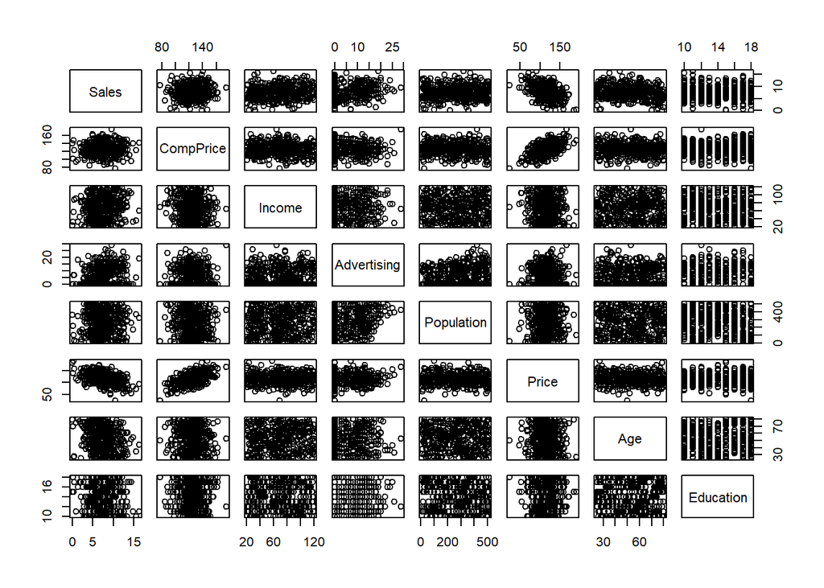

```r
pairs(subset_1)
```

```r
#round(cor(Carseats[,()]), 2)
#library(corrr)
#res.cor %>%
#  focus(-ShelveLoc, -Urban, -US)
```

6. Suppose that we wish to predict sales of car seats (in each location) (that is, the random variable `Sales`) on the basis of the other variables. Do your plots suggest that any of the other variables might be useful in predicting `Sales`? Justify your answer

[output not shown]

## Problem 5 - Splitting the sample into training and testing

```r
library(psych)
library(car)
```

For this problem, continue using the `Carseats` data set.

1. Construct a scatterplot of `Sales` vs `Price`.

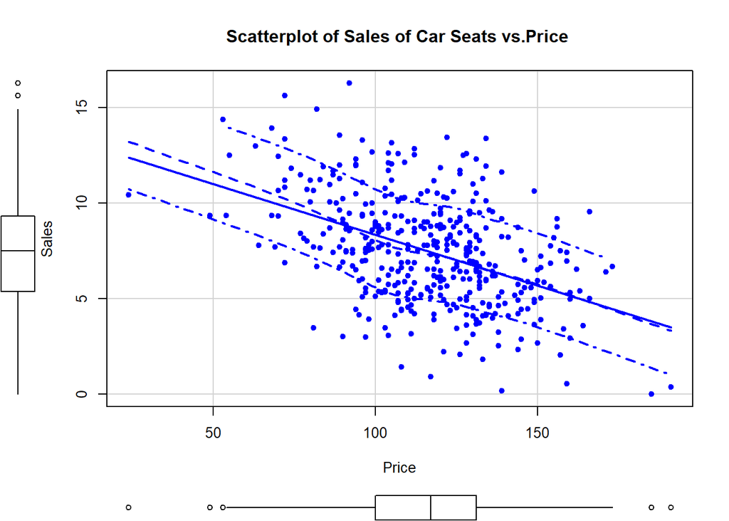

```r
scatterplot(Sales ~ Price, data=Carseats,
            spread=FALSE, smoother.args=list(lty=2), pch=19,
            main="Scatterplot of Sales of Car Seats vs.Price ",
            xlab="Price",

            ylab="Sales")
```

2. Use the `sample()` command to construct `train`, a vector of observation indexes to be used for the purpose of training your model. This will partition the data set into the *training* set and the *testing* set.
   - Describe what the `sample()` function as used above actually does.

[output not shown]

3. Valiadate the partition you obtained for the data. Do you see any issues?
   - *Hint*: this problem is *not* asking you to balance the training data set. It is instead asking you to determine *whether* balancing might be required. To determine that, you should use a hypothesis test! Which test? In `R`, there is *one function* you need to call to get the output for the comparison of two samples. Explain the answer; justify your conclusion.

[output not shown]

## Problem 6 - fitting a multiple linear regression model

This question should be answered using the `Carseats` data set.

1. Fit a multiple regression model to predict `Sales` using `Price`, `Urban`, and `US.`

[output not shown]

2. Provide an interpretation of each coefficient in the model. Be careful—some of the variables in the model are qualitative!

[output not shown]

3. Write out the model in equation form, being careful to handle the qualitative variables properly.

[output not shown]

4. For which of the predictors can you reject the null hypothesis $H_0:\beta_j=0$?

[output not shown]

5. On the basis of your response to the previous question, fit a smaller model that only uses the predictors for which there is evidence of association with the outcome.

[output not shown]

6. How well do the models in (a) and (e) fit the data?

[output not shown]

7. Using the model from (e), obtain 95% confidence intervals for the coefficient(s).

[output not shown]

# Hints & shortcuts

## Exploring a new data set

One of the following may be helpful as you explore the data set:

```
View(Carseats)
help(Carseats)
str(Carseats)
```

## Loops and selections from data frames

You may want to consider some of the following functions or commands as you write code to solve the exam.

```r
tmp_data_set <- mtcars
tmp_col <- tmp_data_set[,1]
tmp_rows <- tmp_data_set[c(1,2,3,5),]
sapply(tmp_data_set[,1:7], max) # applies a function (in this case, `max`) to all of the indicated columns of the data frame
```

```
##     mpg     cyl    disp      hp    drat      wt    qsec
##  33.900   8.000 472.000 335.000   4.930   5.424  22.900
```

# End of final exam, congratulations!

Thank you for joining me on this 514 analytics journey for the first time.

Please stay in touch: I’m on [LinkedIn](https://www.linkedin.com/in/sonjapetrovic/)!

Here is my [homepage link](https://sites.google.com/view/sonjapetrovic).